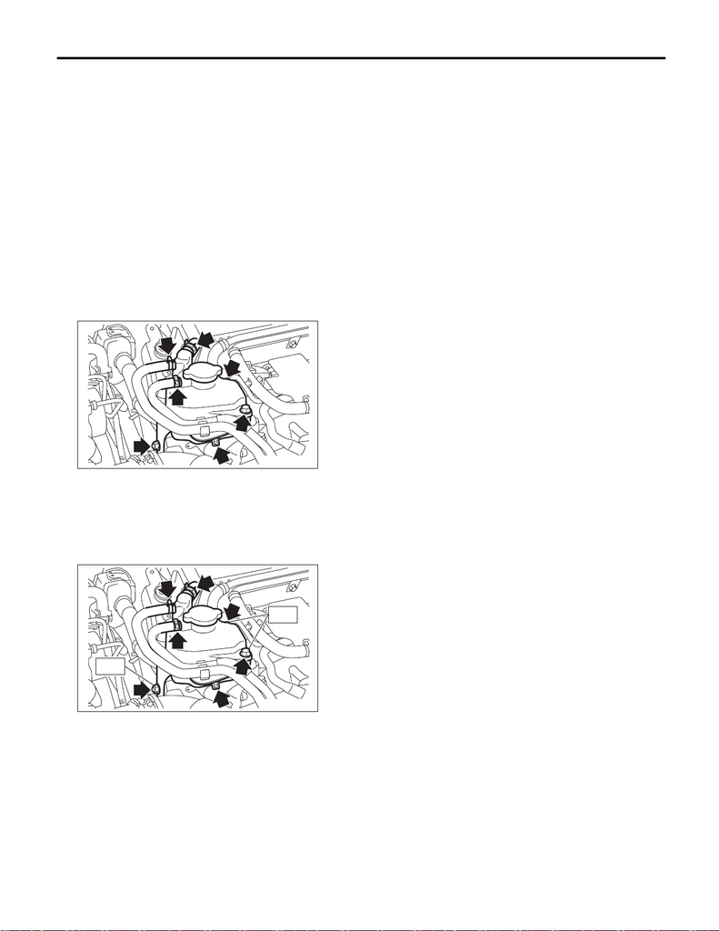

Coolant Filler Tank

COOLING

11.Coolant Filler Tank

A: REMOVAL

CAUTION:

The coolant filler tank is pressurized when the

engine and radiator are hot. Wait until engine

and radiator cool down before working on the

coolant filler tank.

1) Drain approximately 3.0 L (3.2 US qt, 2.6 Imp qt)

of coolant. <Ref. to CO(STI)-13, DRAINING OF

ENGINE COOLANT, REPLACEMENT, Engine

Coolant.>

2) Disconnect the engine coolant hoses from cool-

ant filler tank.

3) Remove the bolt and nut which secure the cool-

ant filler tank.

4) Remove the coolant filler tank.

B: INSTALLATION

1) Install in the reverse order of removal.

Tightening torque:

T1: 13 N·m (1.3 kgf-m, 9.6 ft-lb)

T2: 16 N·m (1.6 kgf-m, 11.8 ft-lb)

C: INSPECTION

1) Check that the coolant filler tank does not have

deformation, cracks or damage.

2) Check that the engine coolant hose has no

cracks, damage or loose part.

T2

T1